# Netflix Data Analysis

#### We are in the process of changing the data type of the "date_added" column from object to datetime to facilitate future analysis.

```python
df['date_added'] = pd.to_datetime(df['date_added'], format='%B %d, %Y', errors='coerce')
```

```python
df.dtypes
```

```
show_id                 object
type                    object
title                   object
director                object
cast                    object
country                 object
date_added      datetime64[ns]
release_year             int64
rating                  object
duration                object
listed_in               object
description             object
dtype: object
```

```python
df.date_added.isnull().sum()
```

```
88
```

```python
df[df.date_added.isnull()]
```

|  | show_id | type | title | director | cast | country | date_added | release_year | rating | duration | listed_in | description |
| --- | --- | --- | --- | --- | --- | --- | --- | --- | --- | --- | --- | --- |
| 6079 | s6080 | TV Show | Abnormal Summit | Jung-ah Im, Seung-uk Jo | Hyun-moo Jun, Si-kyung Sung, Se-yoon Yoo | South Korea | NaT | 2017 | TV-PG | 2 Seasons | International TV Shows, Korean TV Shows, Stand... | Led by a trio of Korean celebs, a multinationa... |
| 6177 | s6178 | TV Show | 忍者ハットリくん | Unknown | Not listed | Japan | NaT | 2012 | TV-Y7 | 2 Seasons | Anime Series, Kids' TV | Hailing from the mountains of Iga, Kanzo Hatto... |
| 6213 | s6214 | TV Show | Bad Education | Unknown | Jack Whitehall, Mathew Horne, Sarah Solemani, ... | United Kingdom | NaT | 2014 | TV-MA | 3 Seasons | British TV Shows, TV Comedies | A history teacher at the posh Abbey Grove, Alf... |
| 6279 | s6280 | TV Show | Being Mary Jane: The Series | Unknown | Gabrielle Union, Lisa Vidal, Margaret Avery, O... | United States | NaT | 2016 | TV-14 | 4 Seasons | Romantic TV Shows, TV Dramas | Ambitious single TV journalist Mary Jane attem... |
| 6304 | s6305 | TV Show | Big Dreams, Small Spaces | Unknown | Monty Don | United Kingdom | NaT | 2017 | TV-G | 3 Seasons | British TV Shows, International TV Shows, Real... | Writer and presenter Monty Don helps England's... |
| ... | ... | ... | ... | ... | ... | ... | ... | ... | ... | ... | ... | ... |
| 8539 | s8540 | TV Show | The Tudors | Unknown | Jonathan Rhys Meyers, Henry Cavill, James Frai... | Ireland, Canada, United States, United Kingdom | NaT | 2010 | TV-MA | 4 Seasons | TV Dramas | All the splendor and scandal of England's 16th... |
| 8557 | s8558 | TV Show | The West Wing | Unknown | Martin Sheen, Rob Lowe, Allison Janney, John S... | United States | NaT | 2005 | TV-14 | 7 Seasons | TV Dramas | This powerful political epic chronicles the tr... |
| 8684 | s8685 | TV Show | Vroomiz | Unknown | Joon-seok Song, Jeong-hwa Yang, Sang-hyun Um, ... | South Korea | NaT | 2016 | TV-Y | 3 Seasons | Kids' TV, Korean TV Shows | For these half-car, half-animal friends, each ... |
| 8712 | s8713 | TV Show | Weird Wonders of the World | Unknown | Chris Packham | United Kingdom | NaT | 2016 | TV-PG | 2 Seasons | British TV Shows, Docuseries, Science & Nature TV | From animal oddities and bizarre science to me... |
| 8755 | s8756 | TV Show | Women Behind Bars | Unknown | Not listed | United States | NaT | 2010 | TV-14 | 3 Seasons | Crime TV Shows, Docuseries | This reality series recounts true stories of w... |

88 rows × 12 columns

Upon inspecting the "date_added" column, it has been observed that 88 rows have been affected by the conversion process, resulting in the loss of these entries. Further evaluation is warranted to determine the significance of these missing values for the dataset and to decide the most appropriate course of action for the analysis.

## Exploratory Data Analysis: Visualization, Observations, and Insights

#### Dataset Overview: Recap of Columns for Enhanced Understanding

```python
df.columns
```

```
Index(['show_id', 'type', 'title', 'director', 'cast', 'country', 'date_added',
       'release_year', 'rating', 'duration', 'listed_in', 'description'],
      dtype='object')
```

```python
df.info()
```

```
<class 'pandas.core.frame.DataFrame'>
Index: 8793 entries, 0 to 8806
Data columns (total 12 columns):
 #   Column        Non-Null Count  Dtype
---  ------        --------------  -----
 0   show_id       8793 non-null   object
 1   type          8793 non-null   object
 2   title         8793 non-null   object
 3   director      8793 non-null   object
 4   cast          8793 non-null   object
 5   country       8793 non-null   object
 6   date_added    8705 non-null   datetime64[ns]
 7   release_year  8793 non-null   int64
 8   rating        8793 non-null   object
 9   duration      8793 non-null   object
 10  listed_in     8793 non-null   object
 11  description   8793 non-null   object
dtypes: datetime64[ns](1), int64(1), object(10)
memory usage: 893.0+ KB
```

```python
sns.set(style="darkgrid")
```

```python
# Top Countries Producing Content:

df.country.value_counts().head(15)
```

```
country
United States     2812
India              972
Unknown            829
United Kingdom     418
Japan              243
South Korea        199
Canada             181
Spain              145
France             124
Mexico             110
Egypt              106
Turkey             105
Nigeria             95
Australia           85
Taiwan              81
Name: count, dtype: int64
```

**Australia:**

- **Despite Australia being a sizable country, the production of movies on Netflix is notably low, with only 85 entries.** This observation raises questions about the representation of Australian content on the platform. Further exploration into the reasons behind this disparity could unveil opportunities for Netflix to collaborate with Australian creators and enhance its content library from the region.

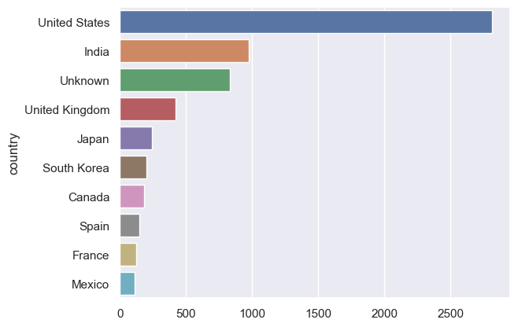

```python
# Visualising content produced by top 10 countries

sns.barplot(y=df.country.value_counts().head(10).index, x=df.country.value_counts().head(10).values)
```

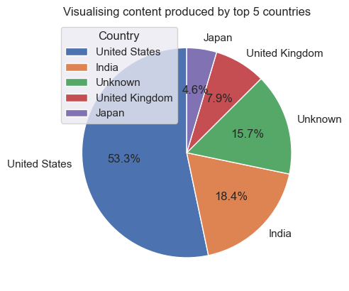

```python
plt.pie(df.country.value_counts().head(5),labels=df.country.value_counts().head().index,startangle=90, autopct='%.1f%%')
plt.legend(loc='upper left', title="Country")
plt.title('Visualising content produced by top 5 countries')
plt.show()
```

```python
# top produced content

df.rating.value_counts().head(10)
```

```
rating
TV-MA    3205
TV-14    2157
TV-PG     861
R         799
PG-13     490
TV-Y7     333
TV-Y      306
PG        287
TV-G      220
NR         79
Name: count, dtype: int64
```

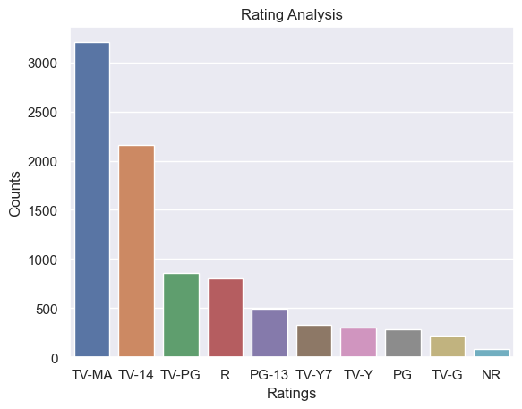

```python
sns.barplot(y=df.rating.value_counts().head(10).values, x=df.rating.value_counts().head(10).index)
plt.title('Rating Analysis')
plt.xlabel('Ratings')
plt.ylabel('Counts')
```

- **Analysis of Ratings:**
  - **TV-MA (Mature Audience):**
    - With 3205 entries, **TV-MA dominates the ratings**, indicating a **substantial demand for adult-oriented content**. This category often includes coarse language, explicit sexual content, nudity, or intense/graphic violence. **The high count suggests a significant audience above 18 years old.**
  - **TV-14 (Parents Strongly Cautioned):**
    - Following closely, TV-14 with 2157 entries signifies content suitable for viewers 14 years and older. Given that these programs may contain material parents find unsuitable for children under 14, **it highlights a sizable teenage audience. Investing in content for this demographic could be strategically advantageous.**
  - **TV-PG (Parental Guidance Suggested):**
    - TV-PG, with 861 entries, denotes content suitable for children under parental guidance. This rating suggests a substantial audience base of families and children. **Recognizing this, Netflix may consider expanding its family-friendly content.**
  - **R (Restricted):**
    - R-rated content, totaling 799 entries, is intended for audiences above 18 years and is not suitable for individuals under this age. The significant count **indicates a robust demand for mature content with strong scenes among adult viewers.** Understanding this customer behavior can guide content production.
  - **PG-13 (Parents Strongly Cautioned):**
    - With 490 entries, the PG-13 rating indicates content that is Parents Strongly Cautioned, as some material may be inappropriate for children under 13. **This suggests a discernible demand among pre-teens and early teenagers for content that may include stronger language, extended violence, sexual situations, or drug-use.** Recognizing this demand allows Netflix to cater to a diverse age group and tailor content accordingly.
  - **TV-Y7 (Directed to Older Children):**
    - With 333 entries, TV-Y7 is directed to older children. The declining count could be attributed to a specific age group preference or a **lesser production focus on content specifically tailored for older children.**
  - **TV-Y (All Children):**
    - TV-Y, with 306 entries, is suitable for all children. The decrease in numbers might be due to a **shift in content preferences towards more targeted age groups**, such as TV-Y7 or other ratings.
  - **PG (Parental Guidance Suggested):**
    - PG, with 287 entries, suggests parental guidance. The decline could be influenced by a **shift in audience preferences towards more specific or mature content,** reducing the demand for content requiring parental guidance.
  - **TV-G (General Audience):**
    - TV-G, with 220 entries for a general audience, may experience a decrease due to a **potential demand for more specialized or age-specific content, resulting in a shift away from general audience programming.**
    - **NR (Not Rated):**
      - With 79 entries not rated (NR), the decline might be linked to a preference for content with explicit ratings, or it could represent a **smaller segment of the overall content library.**

The reasons for declining numbers in these categories could be influenced by evolving viewer preferences, changes in production strategies, or shifts in the target audience for specific content ratings. Further market research and analysis may provide a more comprehensive understanding.

These insights into viewer preferences based on ratings provide valuable information for Netflix to tailor its content strategy to meet diverse audience needs.

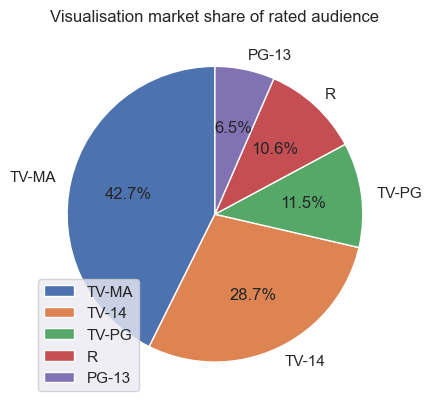

```python
# Visualisation market share of rated audience

plt.pie(df.rating.value_counts().head(5), labels=df.rating.value_counts().head(5).index, startangle=90, autopct='%.1f%%')
plt.title('Visualisation market share of rated audience')
plt.legend()
plt.show()
```

- TV-MA holds the largest market share, constituting approximately 42.7% of the top 5 ratings. This dominance emphasizes a significant demand for mature content, showcasing a substantial audience base for explicit and intense material.
- Following closely, TV-14 holds a noteworthy share, indicating a strong appeal to audiences seeking content suitable for viewers 14 years and older. **Together, TV-MA and TV-14 contribute significantly to Netflix's content landscape.**

Understanding the major market share within the top 5 ratings enables Netflix to strategically focus on content production and curation that aligns with the preferences of a substantial portion of its viewer base.

```python
# Understanding data on the basis of duration

df.duration.value_counts().head(10)
```

```
duration
1 Season     1791
2 Seasons     421
3 Seasons     198
90 min        152
94 min        146
97 min        146
93 min        146
91 min        144
95 min        137
96 min        130
Name: count, dtype: int64
```

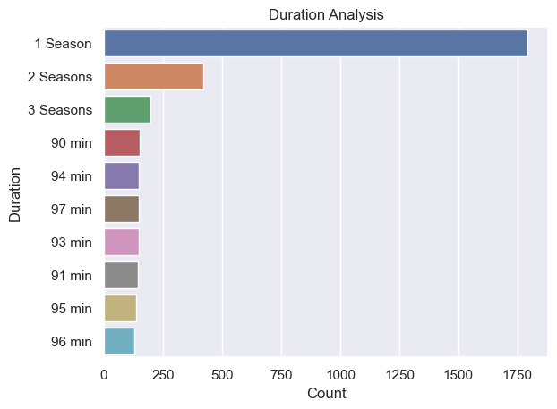

```python
sns.barplot(y=df.duration.value_counts().head(10).index, x=df.duration.value_counts().head(10).values)
plt.title('Duration Analysis')
plt.xlabel('Count')
plt.ylabel('Duration')
plt.show()
```

Understanding the dynamics of content duration helps Netflix tailor its strategy to accommodate both the prevalence of series and the preferred duration for movies, contributing to a more engaging and viewer-friendly content library.

```python
# since India is rapidly growing market, we can see their trends in content

df[df.country=='India'].rating.value_counts().head()
```

```
rating
TV-14    550
TV-MA    248
TV-PG    134
TV-Y7     14
TV-G       9
Name: count, dtype: int64
```

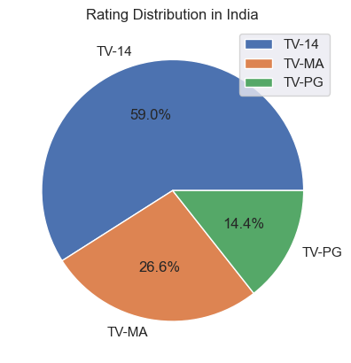

```python
plt.pie(df[df.country=='India'].rating.value_counts().head(3), labels= df[df.country=='India'].rating.value_counts().head(3).index , autopct='%.1f%%')
plt.title('Rating Distribution in India')
plt.legend()
plt.show()
```